# IODS course project

Jue Hou

# Introduction to Open Data Science - Course Project

# About the project

```r
# This is a so-called "R chunk" where you can write R code.

date()
```

```
## [1] "Sat Nov 12 17:58:10 2022"
```

I mostly work with Python nowadays and was using R shortly some time ago. I suppose one of most “challenging” problems for me in this course will probably be debugging in R.

My main goal of this course is to improve my visualization skills. Also, it is always good to review some basic knowledge about data science including regression and clustering, as well as review some common function call or tricks in R.

The repo of this course dairy can be found in `https://github.com/hj940709/IODS-project`

# Regression and model validation

```r
date()
```

```
## [1] "Sat Nov 12 17:58:10 2022"
```

## Load data

```r
library(dplyr)
library(tidyverse)
library(GGally)
```

```r
library(ggplot2)
learning2014 <- read_csv('data/learning2014.csv')
str(learning2014)
```

```
## spc_tbl_ [166 × 7] (S3: spec_tbl_df/tbl_df/tbl/data.frame)
##  $ gender  : chr [1:166] "F" "M" "F" "M" ...
##  $ age     : num [1:166] 53 55 49 53 49 38 50 37 37 42 ...
##  $ attitude: num [1:166] 3.7 3.1 2.5 3.5 3.7 3.8 3.5 2.9 3.8 2.1 ...
##  $ deep    : num [1:166] 3.58 2.92 3.5 3.5 3.67 ...
##  $ stra    : num [1:166] 3.38 2.75 3.62 3.12 3.62 ...
##  $ surf    : num [1:166] 2.58 3.17 2.25 2.25 2.83 ...
##  $ points  : num [1:166] 25 12 24 10 22 21 21 31 24 26 ...
##  - attr(*, "spec")=
##   .. cols(
##   ..   gender = col_character(),
##   ..   age = col_double(),
##   ..   attitude = col_double(),
##   ..   deep = col_double(),
##   ..   stra = col_double(),
##   ..   surf = col_double(),
##   ..   points = col_double()
##   .. )
##  - attr(*, "problems")=<externalptr>
```

This is a dataset collected from an exam. It has 166 observations (row) and 7 variables (col). The variables are `gender`, `age`, `attitude`, `deep`, `surf`, `stra`, and `points`. The value of these variables are mostly numbers, either integer or float, except gender, which is filled with two types of characters: “F” and “M”.

## Graphical overview and variable summary

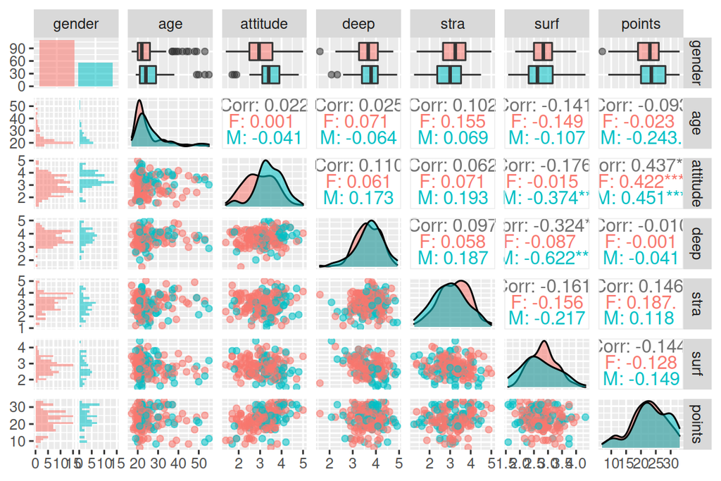

```r
p <- ggpairs(learning2014, mapping = aes(col = gender, alpha = 0.3), lower = list(combo = wrap("facethist", bins = 20)))

p
```

## Fit a linear model and its summary

```r
model <- lm(points ~ attitude + stra + surf, data = learning2014)

summary(model)
```

```
##
## Call:
## lm(formula = points ~ attitude + stra + surf, data = learning2014)
##
## Residuals:
##      Min       1Q   Median       3Q      Max
## -17.1550  -3.4346   0.5156   3.6401  10.8952
##
## Coefficients:
##             Estimate Std. Error t value Pr(>|t|)
## (Intercept)  11.0171     3.6837   2.991  0.00322 **
## attitude      3.3952     0.5741   5.913 1.93e-08 ***
## stra          0.8531     0.5416   1.575  0.11716
## surf         -0.5861     0.8014  -0.731  0.46563
## ---
## Signif. codes:  0 '***' 0.001 '**' 0.01 '*' 0.05 '.' 0.1 ' ' 1
##
## Residual standard error: 5.296 on 162 degrees of freedom
## Multiple R-squared:  0.2074, Adjusted R-squared:  0.1927
## F-statistic: 14.13 on 3 and 162 DF,  p-value: 3.156e-08
```

As what is shown in the previous figure, I select `attitude`, `stra` and `surf` to be the explanatory variable. According to the summary, the coefficient for `attitude`, `stra` and `surf` is 3.3952, 0.8531 and -0.5861 respectively. The intercept of this model is 11.0171.

## Explain and interpret the multiple R-squared of the model

The summary of this model shows that `attitude` is the most significant variable in this model (Pr=1.93e-08), while the other two are less significant (Pr>0.01). This aligns with the coefficients of these three explanatory variables, where the coefficient of `attitude` is the highest absolute value.

The multiple R-squared of this model is 0.207. It is not a high value, which suggests the model is not fully explainable by `attitude`, `stra`, and `surf`. Considering I am using explanatory variables that are most correlated with `points`, it means we either need to consider a more complicated model rather than simple linear regression or there are other missing explanatory variables that are not available from the dataset.

## Diagnostic plots

The assumption of the simple linear model is that all explanatory variables follow a linear relationship with the target variable. The observations and residual should be independent. The residual should also follow the normal distribution.

- Residuals vs Fitted: From this plot, we can see the red curve fluctuate around the perfect horizontal line. Scatter dots #35, #56 and #145 seem to be outliers in this plot.

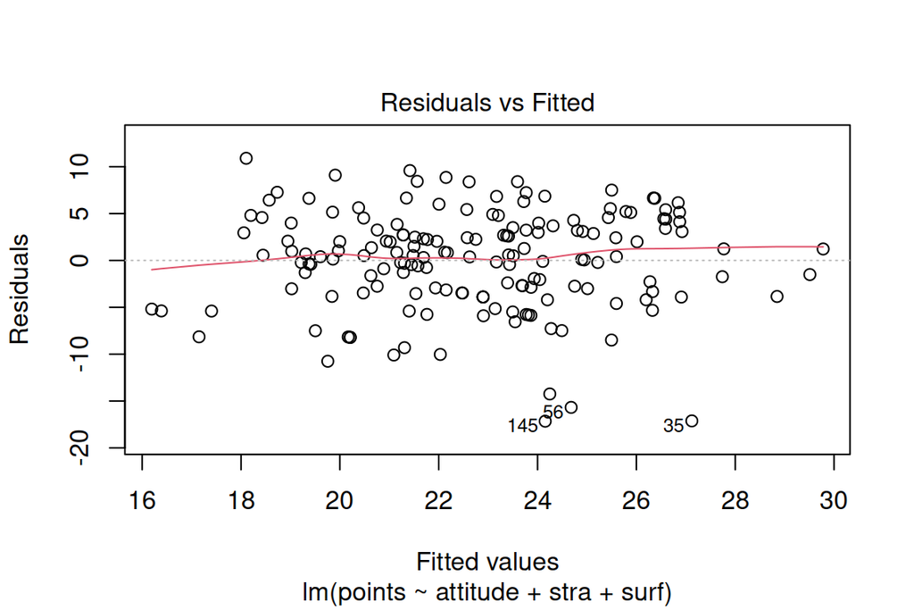

```r
plot(model, which = 1)
```

- Normal QQ-plot: In this plot, we can see the majority of the dots fall along the straight diagonal line. There are a small number of observations that deviate from the line. #35, #56, and #145 seem to deviate the most. We can claim that the residual mostly follows the normal distribution.

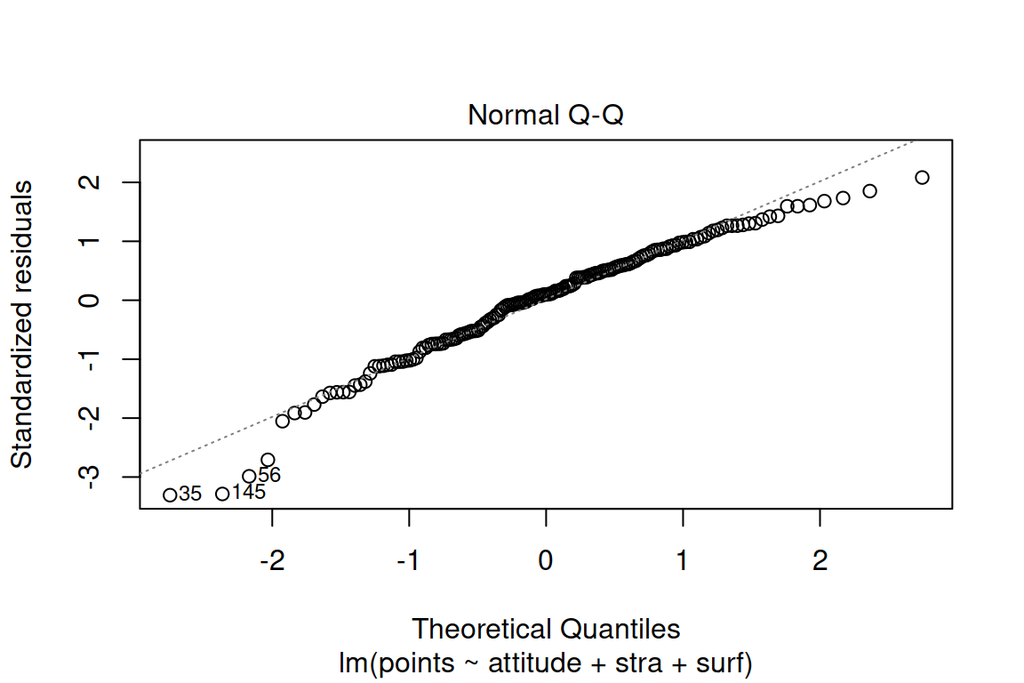

```r
plot(model, which = 2)
```

- Residuals vs Leverage: This plot is supposed to show influential observations according to Cook’s distance. However, I don’t there is a curve for this metric. I suppose it means there aren’t any influential observations in this dataset.

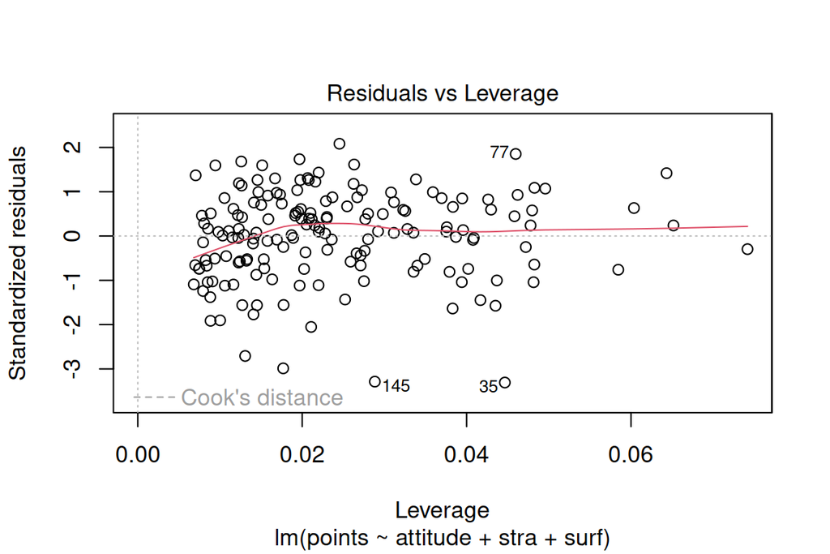

```r
plot(model, which = 5)
```

In conclusion, even though the model is not fully explainable by `attitude`, `stra`, and `surf`. The plots here suggest it is still appropriate to assume these explanatory variables follow a linear patterns in terms of the target variable.